# ¿Qué factores inciden en la confianza en las instituciones públicas en el Perú?

Lévano García_20191128 & Llerena Esquivel_20191353

25/10/2021

Link de Github: https://github.com/Alejangro19/Trabajo_POL304---Grupo-ConeRos-.git

Librerias:

```r
library(dplyr)
library(rio)
```

```r
library(ggplot2)
```

## **¿QUÉ FACTORES INCIDIERON EN LA CONFIANZA EN LAS INSTITUCIONES PÚBLICAS EN EL PERÚ? (2020)**

### **INTRODUCCION:**

En los últimos años, la desconfianza de la población hacia los servicios que brinda el Estado se ha hecho expresa por medio de los estallidos sociales y manifestaciones públicas que han tenido lugar en gran parte de la región latinoamericana. Cabe resaltar que esta no es una problemática nueva para América Latina, pues los niveles de confianza institucional en la región siempre han sido muy bajos a comparación del resto del mundo (Estella de Noriega, 2020). A nivel nacional la situación se replica: los niveles de confianza en las instituciones públicas se mantienen muy bajos desde hace varias décadas, e incluso, el Perú es el país con el nivel de confianza en el Congreso más bajo de la región (Estella de Noriega, 2020).

Se entiende como confianza institucional a la “confianza que las personas tienen en las instituciones”formales"" (Estella de Noriega, 2020). Los autores Cosíos y Vega Centeno (2018) mencionan que la confianza que los ciudadanos tienen en las instituciones públicas “implica una especie de evaluación constante de sus capacidades y decisiones desde la opinión de los ciudadanos”. Por su parte, Benites (2021) sostiene que “esta forma de confianza varía entre los individuos en una sociedad, a partir de las diferentes experiencias, evaluaciones y valores que desarrollan en sus respectivos contextos políticos”.

Es importante conocer la confianza en las instituciones públicas, puesto que ello demuestra cuán satisfechos están los ciudadanos con el funcionamiento del sistema democrático, que busca brindar servicios públicos que permitan el bienestar colectivo. En ese sentido, una alta confianza en las instituciones legítima y aporta a la consolidación de los regímenes democráticos. Sobre ello, Cosíos & Vega Centeno (2018) mencionan lo siguiente:

“El nivel de confianza de la población tiene un rol fundamental, ya que representa un indicador de la evaluación del desempeño de los organismos del Estado. Sobre este tema Bondi (2009) afirma que, si bien la desconfianza genera ciudadanía crítica, la presencia de altos índices de ésta es perjudicial para la consolidación de la democracia”(Cosíos & Vega Centeno, 2018).

La problemática de la confianza institucional ha sido analizada previamente en una serie de investigaciones que buscan conocer este fenómeno a nivel local, nacional y regional (Latinoamérica). En ese sentido, destacamos la relevancia de investigaciones realizadas en los últimos años que buscan conocer qué factores influyen en los niveles de desconfianza institucional, para lo cual plantean diversas hipótesis.

A nivel local, Cohaila (2015) realiza una exhaustiva investigación doctoral que pretende conocer los factores que determinan la confianza en las instituciones locales, el gobierno local, mediante una comparación entre dos distritos de Lima Metropolitana (Los Olivos y San Martín de Porres). Para ello, el autor analiza si existe una relación entre este fenómeno y varias variables explicativas, a partir de lo cual encuentra que sí se relacionan los factores del clientelismo, la inclusión real y la satisfacción con la democracia local.

A nivel nacional, Benites (2021) realizó una reciente investigación acerca de los determinantes de los niveles de confianza institucional en las y los ciudadanos peruanos. A partir de este estudio, encuentra que este fenómeno puede ser explicado a partir del desempeño que tienen las instituciones; adicionalmente, descarta el supuesto de que esta confianza está determinada por la presencia de valores democráticos en la ciudadanía.

En el ámbito regional, Estella de Noriega (2020) plantea un estudio comparativo entre el nivel de confianza general e institucional a nivel de los países latinoamericanos. El autor emplea los datos del Latinobarómetro desde 1996 hasta el año 2018, con el fin de encontrar tendencias a nivel regional, diferencias entre los países, instituciones que presentan niveles más elevados de desconfianza, entre otros puntos que se evalúan. A partir de esta revisión y comparación de datos, plantea como hipótesis que la baja confianza institucional sería resultado de la performance de las instituciones evaluadas; no obstante, su estudio deja abierta esta respuesta tentativa a futuras investigaciones.

Pese a que se trata de un fenómeno que se ha estudiado previamente, en este trabajo se busca determinar si existen otros factores adicionales que se relacionan también con esta desconfianza, en los cuales no se ha profundizado. De tal manera, el objetivo general de esta investigación es encontrar qué factores estarían influyendo en la baja confianza en las instituciones públicas que existe actualmente en el Perú. Como objetivos específicos nos planteamos dos. El primero de ellos es encontrar cuánto aportan cada una de estas variables a los niveles de confianza en las instituciones públicas. Además, a partir de estos resultados se podría reconocer en qué aspectos deben ser mejorados o tomados en cuenta para que se tenga una mejor percepción de estas instituciones (objetivos específicos del reporte)

Por ello, es importante encontrar los factores que condicionan esta baja confianza en las instituciones públicas peruanas. En esa línea, la pregunta de investigación de este trabajo será averiguar qué factores inciden en la confianza en las instituciones públicas peruanas. Para responder esta pregunta, en un primer momento se plantea como hipótesis que tanto la percepción sobre la democracia, como un conjunto de factores socioeconómicos tienen una alta incidencia en la predicción de la confianza en las instituciones. Entre estos últimos, se encuentran el acceso a servicios básicos tales como el acceso al agua potable, al servicio de electricidad, acceso a la salud, acceso a la educación (años de estudio), y los ingresos percibidos por hogar.

### **Base de Datos a utilizar: Encuesta Nacional de Hogares 2020**

Para comprobar la validez de la respuesta tentativa, se realizará un análisis cuantitativo a partir de la base de datos de la Encuesta Nacional de Hogares (ENAHO) del año 2020, realizada por el Instituto Nacional de Estadística e Informática (INEI), de la cual se extraerán las variables de estudio de interés.

Previamente usamos las bases de datos correspodientes a las secciones Educacion_Enaho01A_2020_300, Empleo_e_Ingresos, GBT_Enaho01B_2020_1 y Caracteristicas_de_la_vivienda_y_el_hogar; para crear un dataframe con solo las variables a utliizar.

La base creada, toma el nombre de nuestro grupo: “coneros”

```r
coneros <- import("https://raw.githubusercontent.com/Alejangro19/Trabajo_POL304---Grupo-ConeRos-/main/coneros.csv")
```

### CODIFICACIÓN DE LAS VARIABLES:

#### **VARIABLE DEPENDIENTE:**

**Confianza en las Instituciones Públicas (P1$01:P1$21)**

Para comprobar la validez de la respuesta tentativa, se realizará un análisis cuantitativo a partir de la base de datos de la Encuesta Nacional de Hogares (ENAHO) del año 2020, realizada por el Instituto Nacional de Estadística e Informática (INEI), de la cual se extraerán las variables de estudio de interés. Como variable dependiente, se creará un índice de confianza en las instituciones públicas a partir de las preguntas P1$01 hasta la P1$21 (se puede encontrar las variables de esta forma en la base de datos y en el diccionario de datos). En estas preguntas, se ha encuestado sobre la confianza de los ciudadanos en distintas instituciones, tales como el Jurado Nacional de Elecciones (JNE), la ONPE, la RENIEC, las municipalidades, la Policía Nacional del Perú (PNP), la Defensoría del Pueblo, el Congreso del Perú, los partidos políticos, entre otras instituciones. Posteriormente, el índice creado será dividido en cuatro, con el fin de ordenar el nivel de confianza en categorías de menor a mayor: muy baja, baja, alta y muy alta confianza.

De acuerdo a la encuesta, el valor 5 equivale a “No sabe” y por tanto transformaremos estos numeros en NAs.

```r
str(coneros$`P1$01`)
```

```
##  int [1:35160] 1 1 2 2 2 2 2 2 2 2 ...
```

```r
table(coneros$`P1$01`)
```

```
##
##     1     2     3     4     5
## 10514 15226  4067   995  4358
```

```r
coneros$`P1$01`[coneros$`P1$01` == 5] <- NA
coneros$`P1$02`[coneros$`P1$02` == 5] <- NA
coneros$`P1$03`[coneros$`P1$03` == 5] <- NA
coneros$`P1$04`[coneros$`P1$04` == 5] <- NA
coneros$`P1$05`[coneros$`P1$05` == 5] <- NA
coneros$`P1$06`[coneros$`P1$06` == 5] <- NA
coneros$`P1$07`[coneros$`P1$07` == 5] <- NA
coneros$`P1$08`[coneros$`P1$08` == 5] <- NA
coneros$`P1$09`[coneros$`P1$09` == 5] <- NA
coneros$`P1$10`[coneros$`P1$10` == 5] <- NA
coneros$`P1$01`[coneros$`P1$11` == 5] <- NA
coneros$`P1$12`[coneros$`P1$12` == 5] <- NA
coneros$`P1$13`[coneros$`P1$13` == 5] <- NA
coneros$`P1$14`[coneros$`P1$14` == 5] <- NA
coneros$`P1$15`[coneros$`P1$15` == 5] <- NA
coneros$`P1$16`[coneros$`P1$16` == 5] <- NA
coneros$`P1$17`[coneros$`P1$17` == 5] <- NA
coneros$`P1$18`[coneros$`P1$18` == 5] <- NA
coneros$`P1$19`[coneros$`P1$19` == 5] <- NA
coneros$`P1$20`[coneros$`P1$20` == 5] <- NA
coneros$`P1$21`[coneros$`P1$21` == 5] <- NA
```

Sumamos las variables anteriores para crear un indice que mida la confianza en las Instituciones Públicas

```r
coneros$confi <-  coneros$`P1$01`+coneros$`P1$02`+coneros$`P1$03`+coneros$`P1$04`+coneros$`P1$05`+coneros$`P1$06`+coneros$`P1$07`+coneros$`P1$08`+coneros$`P1$09`+coneros$`P1$10`+coneros$`P1$11`+coneros$`P1$12`+coneros$`P1$13`+coneros$`P1$14`+coneros$`P1$15`+coneros$`P1$16`+coneros$`P1$17`+coneros$`P1$18`+coneros$`P1$19`+coneros$`P1$20`+coneros$`P1$21`
summary(coneros$confi)
```

```
##    Min. 1st Qu.  Median    Mean 3rd Qu.    Max.    NA's
##   21.00   32.00   40.00   40.03   47.00   84.00   12061
```

```r
coneros$confi <- (coneros$confi-21)/63*100
```

La convertimos en una variable ordinal de 4 niveles: “muy baja”, “baja”, “alta” , “muy alta” [confianza en las instituciones], cada 25 unidades

```r
summary(coneros$confi)
```

```
##    Min. 1st Qu.  Median    Mean 3rd Qu.    Max.    NA's
##    0.00   17.46   30.16   30.21   41.27  100.00   12061
```

```r
coneros$confi = cut(coneros$confi, breaks = c(0,25,50,75,100),
                                  include.lowest = T, ordered_result = T,
                                  labels = c("muybaja", "baja",
                                        "alta", "muyalta"))
prop.table(table(coneros$confi))*100
```

```
##
##    muybaja       baja       alta    muyalta
## 37.8328066 49.7943634 11.7018053  0.6710247
```

Descripción de la Variable:

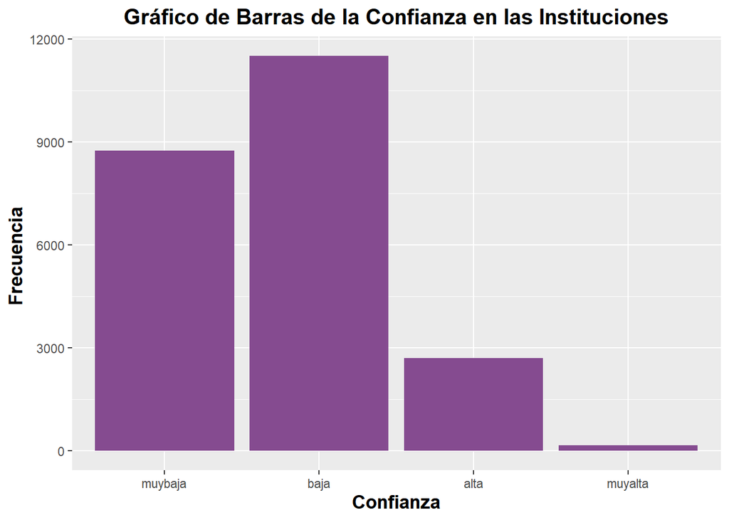

```r
coneros %>%
 filter(!is.na(confi)) %>%
 ggplot() +
  aes(x = confi) +
  geom_bar(fill = "#854B90") +
  labs(
    x = "Confianza",
    y = "Frecuencia ",
    title = "Gráfico de Barras de la Confianza en las Instituciones"
  ) +
  theme_gray() +
  theme(
    plot.title = element_text(
      size = 15L,
      face = "bold",
      hjust = 0.5
    ),
    axis.title.y = element_text(
      size = 13L,
      face = "bold"
    ),
    axis.title.x = element_text(
      size = 13L,
      face = "bold"
    )
  )
```

#### **VARIABLES INDEPENDIENTES**

**Servicios Públicos:**

Utilizaremos como variables independientes al acceso a algunos servicios públicos. Cabe resaltar que trabajaremos estas variables relacionadas al acceso a los servicios básicos como dicotómica, es decir, cuentan con dos posibles respuestas: contar con el acceso al servicio o no.

```r
coneros <- rename(coneros, agua=P110A1, electricidad=P1121, desagüe=P111A, internet=P1144)
```

Acceso a agua potable (P110A1)

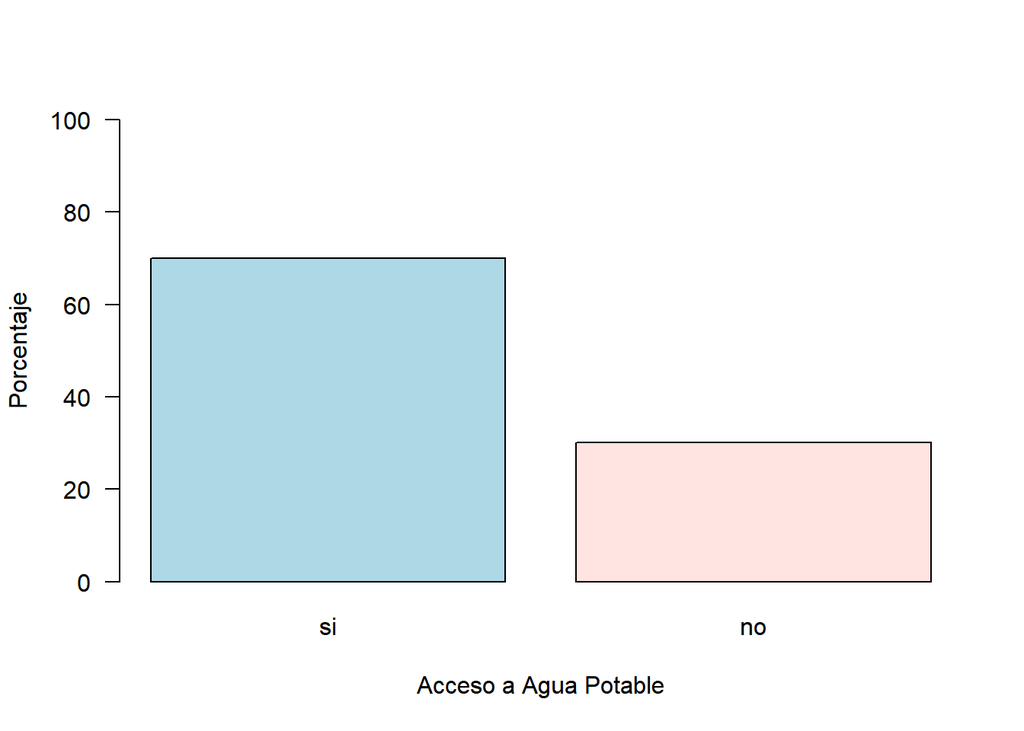

```r
coneros$agua <- as.factor(coneros$agua)
levels(coneros$agua) <- c("si","no")
tagua <- prop.table(table(coneros$agua))*100
barplot(tagua,
        beside = TRUE, las=1,
        xlab='Acceso a Agua Potable', ylab='Porcentaje',
        col = c("lightblue", "mistyrose"),
        ylim = c(0, 100))
```

Acceso a Electricidad (P1121)

```r
str(coneros$electricidad)
```

```
##  int [1:35160] 1 1 1 1 1 1 1 1 1 1 ...
```

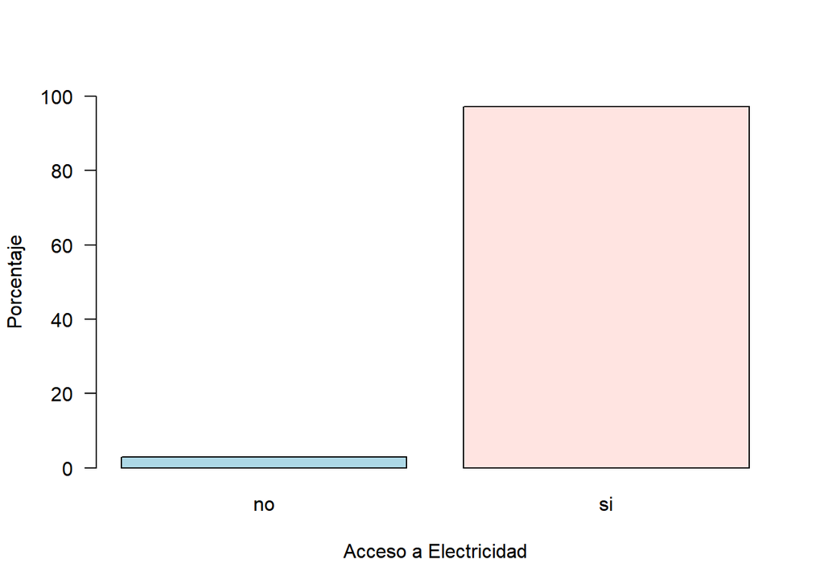

```r
coneros$electricidad <- as.factor(coneros$electricidad)
levels(coneros$electricidad) <- c("no","si")
telectri <- prop.table(table(coneros$electricidad))*100
barplot(telectri,
        beside = TRUE, las=1,
        xlab='Acceso a Electricidad', ylab='Porcentaje',
        col = c("lightblue", "mistyrose"),
        ylim = c(0, 100))
```

El gráfico de la variable “acceso a electricidad” nos permite conocer que cerca de la totalidad (más del 90%) de los encuestados dice contar con acceso a este servicio. En ese sentido, el “sí tener acceso a la electricidad” es la moda.

Acceso a desagüe (P111A)

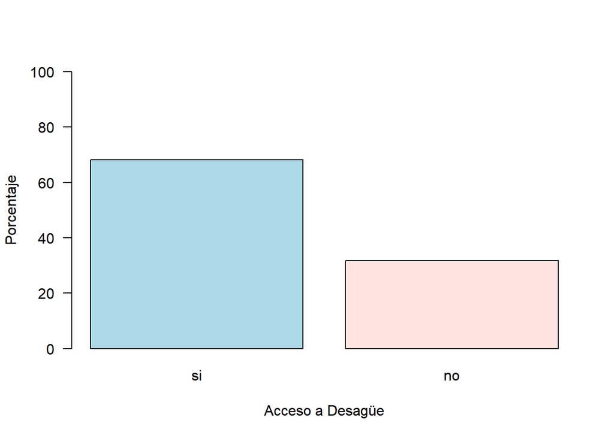

```r
coneros$desagüe = cut(coneros$desagüe, breaks = c(0,2,9),
                                  include.lowest = T, ordered_result = F,
                                  labels = c("si","no"))
tdesa <- prop.table(table(coneros$desagüe))*100
barplot(tdesa,
        beside = TRUE, las=1,
        xlab='Acceso a Desagüe', ylab='Porcentaje',
        col = c("lightblue", "mistyrose"),
        ylim = c(0, 100))
```

Acceso a Internet (P1144)

```r
str(coneros$internet)
```

```
##  int [1:35160] 1 1 0 0 1 1 1 1 1 1 ...
```

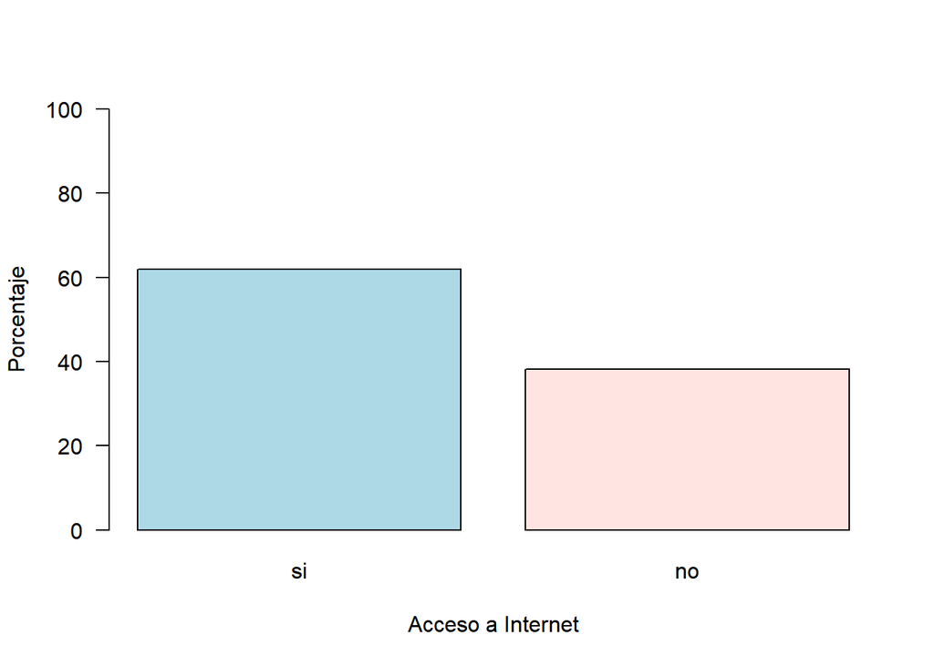

```r
coneros$internet <- as.factor(coneros$internet)
levels(coneros$internet) <- c("si","no")
tinternet <- prop.table(table(coneros$internet))*100
barplot(tinternet,
        beside = TRUE, las=1,
        xlab='Acceso a Internet', ylab='Porcentaje',
        col = c("lightblue", "mistyrose"),
        ylim = c(0, 100))
```

**Ingreso Monetario:**

Se tomará en cuenta para el análisis la variable “ingresos monetarios percibidos por familia”. Esta es una variable numérica, por lo cual podemos obtener y analizar su media, mediana, moda, a partir de la función summary.

```r
summary(coneros$P530A)
```

```
##    Min. 1st Qu.  Median    Mean 3rd Qu.    Max.
##     1.0   123.0   396.0   790.3   960.0 50000.0
```

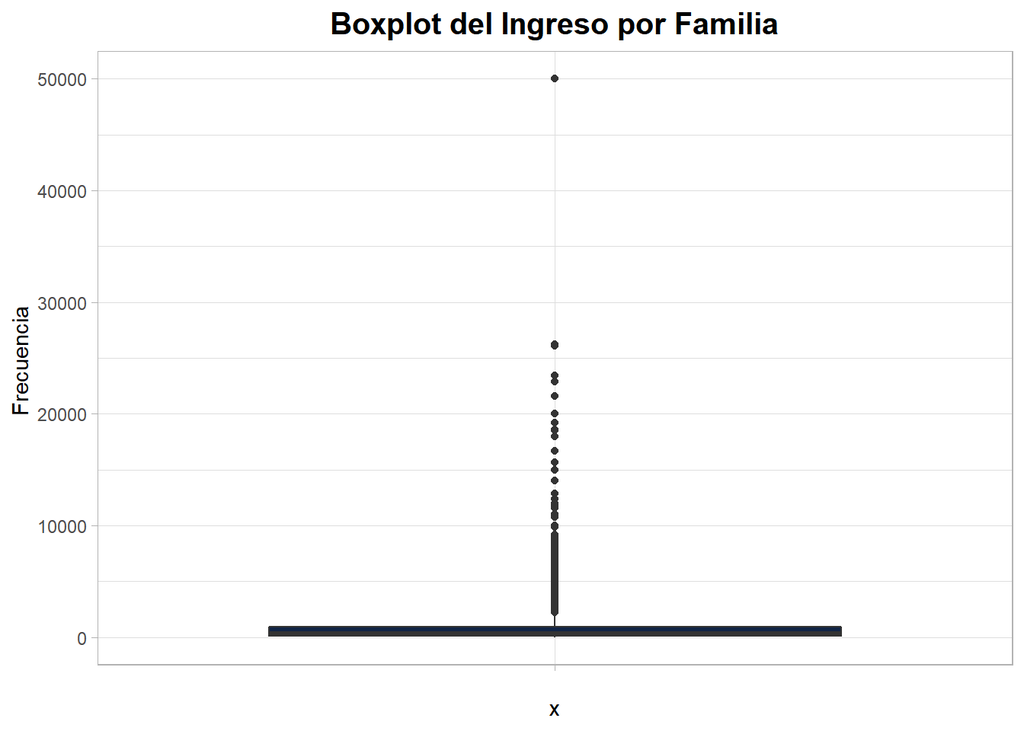

```r
coneros %>%
 filter(!is.na(P530A)) %>%
 ggplot() +
  aes(x = "", y = P530A) +
  geom_boxplot(shape = "circle", fill = "#112446") +
  labs(
    y = "Frecuencia ",
    title = "Boxplot del Ingreso por Familia"
  ) +
  theme_light() +
  theme(
    plot.title = element_text(
      size = 15L,
      face = "bold",
      hjust = 0.5
    )
  )
```

**Percepción sobre la Democracia**

Creemos que la percepción sobre la democracia de los peruanos también servirá como variable independiente

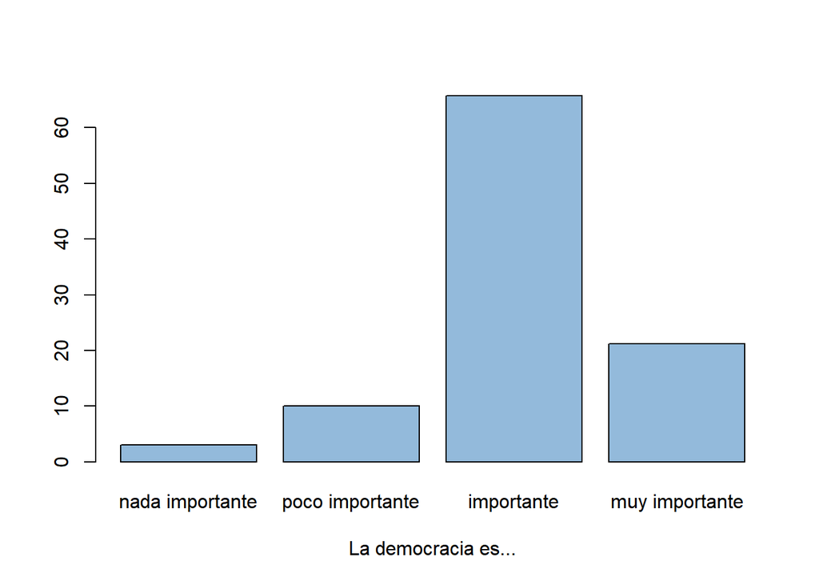

```r
coneros$P6[coneros$P6 == 5] <- NA
coneros$P6 <- as.ordered(coneros$P6)
levels(coneros$P6) <- c("nada importante","poco importante","importante","muy importante")
barplot(prop.table(table(coneros$P6))*100, xlab = "La democracia es..." , co = "#93BADB")
```

La variable “percepción sobre la democracia” es una categórica ordinal, obtenida a partir de la pregunta “P6”, que interroga sobre cuán importante consideran las y los encuestados que es la democracia en el país. En ese sentido, la variable tiene cuatro categorías, que se ordenan de menor a mayor: nada importante, poco importante, importante y muy importante.

Mediante la visualización gráfica de la variable, se observa que la moda de la variable es “importante”, es decir, hay una mayor frecuencia de encuestados que considera que la democracia es importante en el Perú (más del 60%). Además, es resaltante que para casi la totalidad de los encuestados la democracia tiene cierta importancia, puesto que aquellos que señalan que no es “nada importante”, se acercan al 0%.

### POSIBLE PRUEBA A UTILIZAR:

A partir de las variables propuestas, una posible prueba estadística a utilizar es el Modelo de Regresión Logística Ordinal. Se emplea este modelo, puesto que se tiene una variable dependiente de tipo ordinal, el índice de confianza en las instituciones públicas, el cual cuenta con cuatro categorías que pueden ser ordenadas de menor a mayor (muy baja, baja, alta, muy alta). De esta manera, el modelo de regresión ordinal permitirá modelar y predecir el efecto de nuestras variables independientes propuestas en el nivel de confianza que tienen los ciudadanos hacia las instituciones públicas peruanas, en el año 2020.